# DataViz Makeover 1

#### **Step 8:**

Formatting x-axis is slightly more tricky. Due to the limited space, we face the following issues for each subplot:

- not able to display label for all quarters. (i.e. cannot use 2019 Q1, 2019 Q2,…, 2020 Q4)
- not able to display simplified labels either (i.e. cannot use Q1, Q2, Q3, Q4, Q1, Q1, Q2, Q3, Q4)
- not able to display the year to split the Quarters without splitting area chart per country which is not what we want. (If we add year, it will be added as a dimension variable and tableau will automatically displays it on top. If we use only dimension variable, the graphs will split as mention.)

Hence to overcome these issues, we worked around it:

First let us format the x-axis such that it displays Q1,Q2 etc. Right click on the x-axis and selecting format will open the format pane on the left. Under Scale, `Dates`, we select Custom and key in “Q”q.

We can see the changes immediately on the right.

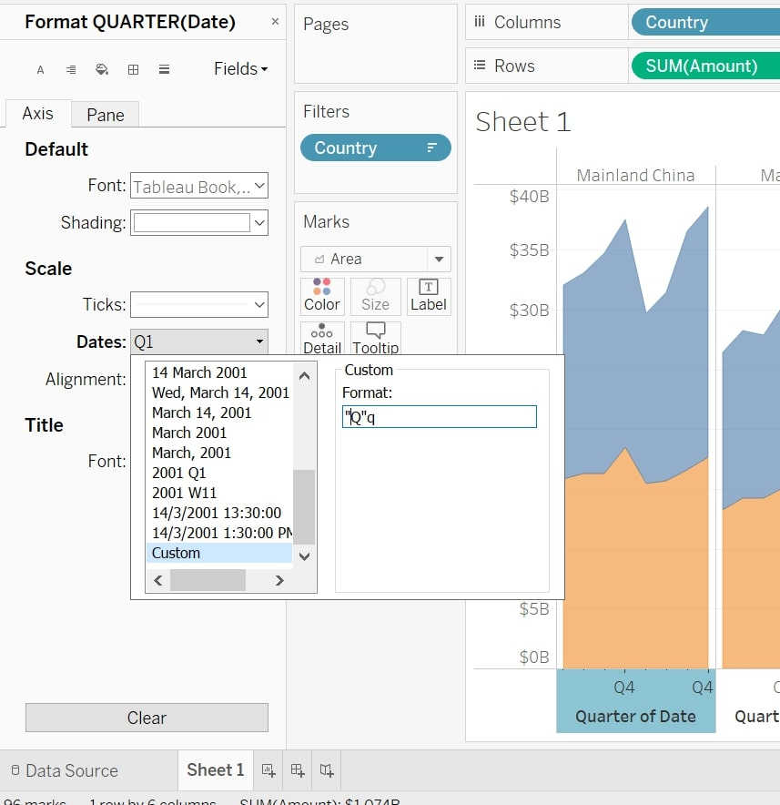

Let us also change all the font size under Default and Title to size 8, Tableau Book.

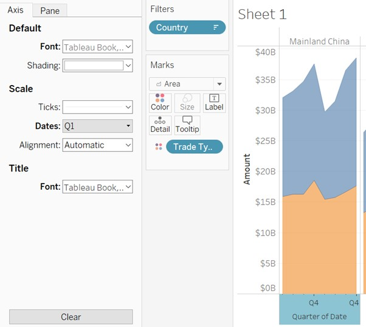

Next we right click on the x-axis to Edit axis, and click on the tab Tick Marks We uncheck Show times as this is irrelevant for us. We will do the following changes:

- Major Tick Marks
  - select Fixed
  - Tick origin: 1/1/2019
  - Interval: 2
  - Unit: Quarters
- Minor Tick Marks
  - select Fixed
  - Tick origin: 1/4/2019
  - Interval: 2
  - Unit: Quarters

Now we can see that there are tick marks every quarter. The major tick marks will mark Q1 and Q3.

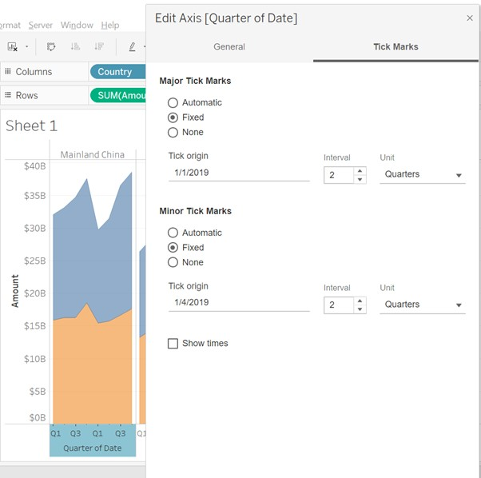

Switch to General to update the Axis Title by keying in “2019 | 2020” into Title This is the little trick to label the year in the x-axis since the title will always be centered for each subplot.

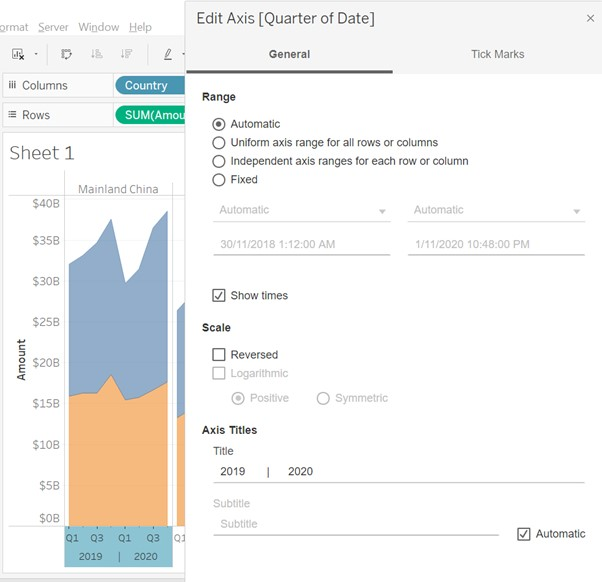

Now we have a good x-axis with consistent width, consistent tick marks, sufficient labels. This is the end result:

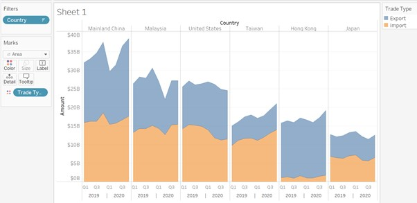

#### **Step 9:**

Next we want to add circles to the total merchandise trade to indicate the points more clearly. Unfortunately, Tableau does not provide the option of adding shapes or marks to the individual points for area charts unlike line chart. Hence, we need to work around it by using dual axis.

First, we drag Amount to the right side of the chart until we see a dotted line. This will duplicate the same chart only with the y-axis on the right this time. If we look at the card under Marks, there is now additional cards. We pick the second one and make the following changes:

- Change Area to Circle in the dropdown
- Remove Trade type from colos as we do not need to split the data
- change the colour to something darker for visibility
- change the size to something smaller so that it does not overwhelm the visualization.

The results will be something like this:

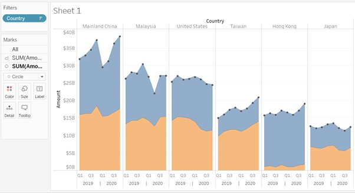

#### **Step 10:**

Let us be a bit more specific with our titles. For the title at the y-axis, let us rename it as “Merchandise Trade Amount” For the “Country” at the top, it is rather redundant and so we will remove it. For the overall title we will write: “Singapore’s Top Six Merchandise Trading Partners (2019-2020)”

Let us also adjust the font size and font for consistency and so that attention is in the right place:

- Title Format: Tableau Light, size 15, Bold
- “Country” Format: Tableau Book, size 9, colour html: #555555
- y-axis title Format: Tableau Book, size 9, colour html: #555555

The results will be something like this:

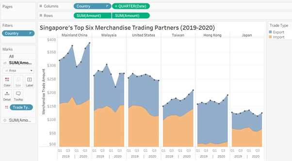

#### **Step 11**

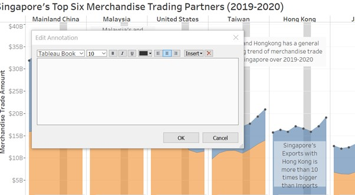

One unique even that happened in 2020 is the spreading of COVID, which affected the whole world. To highlight that period, we added a reference band. On the x-axis, right click to select `Add Reference Line`. A window will pop-up. As we would like to highlight a segment for each country, we select `Band`, `Per Pane`, ensuring that the date values in `Band From` is “1/1/2020” and date values in `Band To` is “1/4/2020”. Next, we edit the `Label` to `Custom`, entering “Covid Worsen in SG”, putting the `Label` to `None` under `Band To` so that only one label will appear.

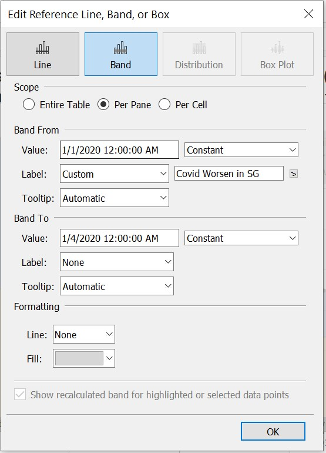

## 4 Derived Insights

### Insight 1

Singapore’s top 6 merchandise trading partners are as follows, ranked in descending order:

1. Mainland China
2. Malaysia
3. United States
4. Taiwan
5. Hong Kong
6. Japan

This ranking does not surprise us. As the [world’s manufactoring superpower](https://www.statista.com/chart/20858/top-10-countries-by-share-of-global-manufacturing-output/) and given geographical proximity, it is natural for China to become the highest merchandise trading partner of Singapore. This is followed by Malaysia, just by virtue of the fact that Singapore and Malaysia are neighbours and transporting goods are made convenient. The United States comes a close third as the [third largest global merchandise exporter](https://www.statista.com/topics/1308/trade-in-the-us/#:~:text=In%202018%2C%20the%20United%20States,the%20world's%20total%20export%20trade.). Followed by Taiwan, Hong Kong and Japan which are all in Asia. It is also interesting to note that all 6 countries have [Free Trade Agreements](https://www.mti.gov.sg/-/media/MTI/improving-trade/FTAs/All-you-need-to-know-about-SG-FTAs-and-DEAs.pdf) with Singapore.

Even though there is a clear ranking, we can also see from the visualization that there is no one country’s trade that exceeds other countries’ trade by a large proportion which implies that Singapore does not solely rely on a single country for imports and exports.

### Insight 2

If we observe the proportions of the export and imports in the visualization, we can see an exception where Singapore’s trade exports with Hong Kong is at least 10 times bigger than that of imports resulting in a large merchandise trade surplus. (This only occurs with Hong Kong and not with any of the other 6 countries.) It seems that Hong Kong is at the disadvantage here, however, knowing that Hong Kong has close relations with Singapore, it is likely that Hong Kong benefits from Singapore through means other than merchandise trading.

[Notes about trade](https://www.thebalance.com/balance-of-trade-definition-favorable-vs-unfavorable-3306261): + Trade surplus (positive trade balance) -> when exports exceed imports + Trade deficit (Negative trade balance) -> when exports are less than imports + Trade surplus is harmful when government uses protectionism + Otherwise, most countries will strive for Trade surplus

### Insight 3

In 2020 Q1-Q2 was when COVID situation worsened in Singapore, resulting in circuit breaker where many work places had to be shut down for 2 months except for essential services. It is expected that [trade (especially exports) fall](https://www.channelnewsasia.com/news/business/singapore-exports-q3-third-quarter-oil-nodx-13619218) during this period. This is apparent for Mainland China and Malaysia where we observe a relatively larger dip in trade in this period. There is a slight decrease in trade during this period for the other countries except for Taiwan and it could be that the goods that Singapore trade with Taiwan remains unaffected by the COVID situation.